# 36-315 Lab 08

SOLUTIONS

Due Saturday, October 30, 2021 (12pm via Gradescope)

## Lab 08: Dendrograms and Principal Component Analysis

# Problem 1: Dendrograms (50pts)

In this lab, we will again work with the student performance dataset used in Homework6. Here’s the code to read in the data:

```r
data = read.csv("https://raw.githubusercontent.com/zjbranson/315Fall2021/master/students.csv")
```

Details about the dataset are found [here](https://www.kaggle.com/aljarah/xAPI-Edu-Data).

It’s actually easier to make fine-looking dendrograms in base `R`, so we are going to focus on using base `R` (instead of `ggplot`) for making dendrograms.

1. (10pts) First, perform the following steps:
- Create a subset of the student data that only contains the four quantitative variables `RaisedHands`, `VisitedResources`, `AnnouncementsView`, and `Discussion`. Define this as `data.subset`.

```r
data.subset = subset(data, select = c(RaisedHands, VisitedResources, AnnouncementsView, Discussion))
```

- **Standardize your variables** by dividing each column by its standard deviation.

```r
data.subset = apply(data.subset, MARGIN = 2, FUN = function(x) x/sd(x))
```

- Create a distance matrix using the Euclidean distance using the `dist` function. Define this as `data.subset.dist`.

```r
data.subset.dist = dist(data.subset)
```

If you’ve done this correctly, you should be able to run the following line of code:

```r
dim(as.matrix(data.subset.dist))
```

```
## [1] 480 480
```

You should get a 480-by-480 matrix, which represents the *distance matrix* for this dataset. (If you don’t, something must have gone wrong - please ask for help if you get stuck.) Furthermore, you should be able to run the following lines of code:

```r
mean(as.matrix(data.subset.dist)[1,])
```

```
## [1] 2.668366
```

```r
mean(as.matrix(data.subset.dist)[,1])
```

```
## [1] 2.668366
```

After you’ve done this: In 1-3 sentences, explain why the two numbers produced by the above code are the same. (Feel free to wait until after the lab to write a formal answer to this part, but please ask for help if you don’t immediately know the answer to this one.)

*Any distance matrix is an $n \times n$ matrix, where $n$ denotes the number of subjects. Any $[i,j]$ entry of the matrix denotes the distance between subject $i$ and subject $j$. Thus, the first row of the matrix denotes the distances between the first subject and all the other subjects; similarly, the first column also denotes the distances between the first subject and all the other subjects. In other words, the $i$th row and $i$th column of any distance matrix will contain the same numbers. Thus, both numbers above represent the average distance between the first subject and all other subjects.*

2. (10pts) Now we are going to plot a dendrogram (using “complete linkage” hierarchical clustering) of the student dataset. Perform the following tasks:
- Define a “hierarchical clustering” object, `student.hc`, defined using the `hclust()` function, which takes in a *distance matrix* as an argument. So, put in the distance matrix `data.subset.dist` that you created in Part A. Furthermore, within `hclust()`, set `method = "complete"` to specify that you are running “complete linkage” as the hierarchical clustering technique. (If you wanted to run “single linkage” - which you’ll have to do on the homework - you’d specify `method = "single"`.)

```r
student.hc = hclust(data.subset.dist, method = "complete")
```

- After you’ve appropriately defined `student.hc`, convert it to a dendrogram-type object by running the following line of code:

```r
student.hc.dend = as.dendrogram(student.hc)
```

Note that it’s important to convert the `hclust()` object to a dendrogram using `as.dendrogram()`; this will allow us to plot and modify the dendrogram later on.

- Run `plot(student.hc.dend)`.

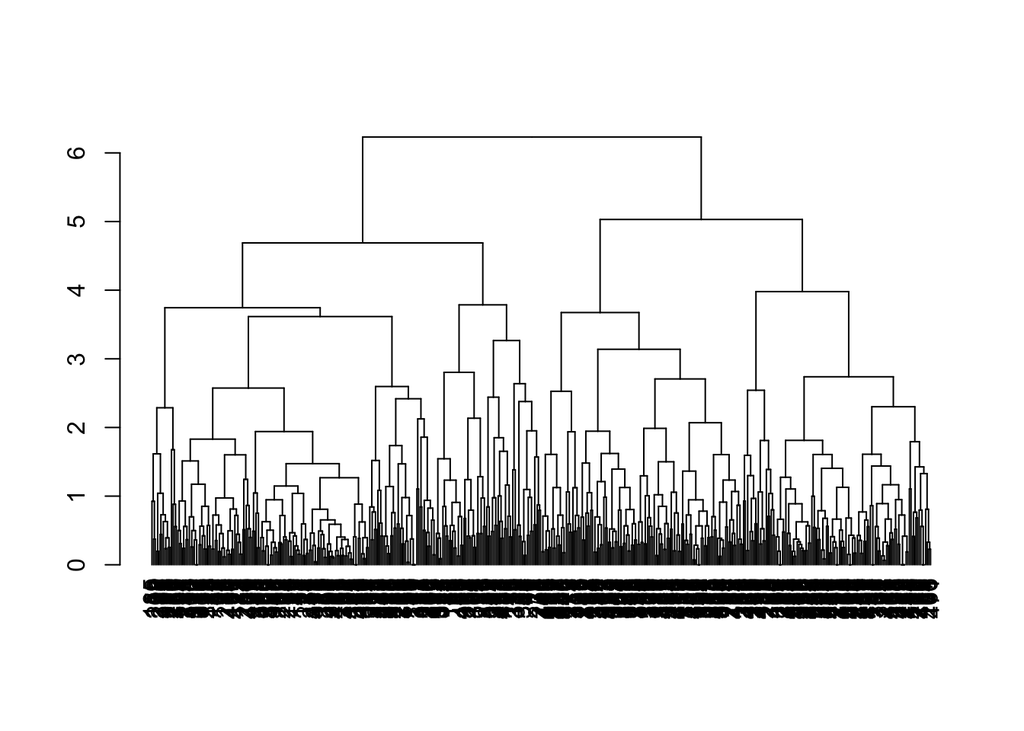

```r
plot(student.hc.dend)
```

For this part, just submit the plotted dendrogram (it’s okay if there are messy leaf labels at the bottom of the plot).

3. (15pts) It can be helpful to color the tree by the clusters it naturally divides itself into. To do this, you’ll need the `R` package `dendextend`, so please install that package if you haven’t already. Be sure to load the library with the line `library(dendextend)`.

Within the `dendextend` library, there is a function called `set` that is commonly used to alter aspects of a dendrogram plot. Unfortunately, you can only “set” one aspect of a dendrogram at a time, so it is a bit tedious to use (i.e., you have to write multiple lines of code using the `set` function). However, it’s not that hard once you learn how to do it. You’ll have to use the `set` function on the homework.

The following lines of code produces a dendrogram with branches colored by the $k = 3$ clusters identified by the dendrogram:

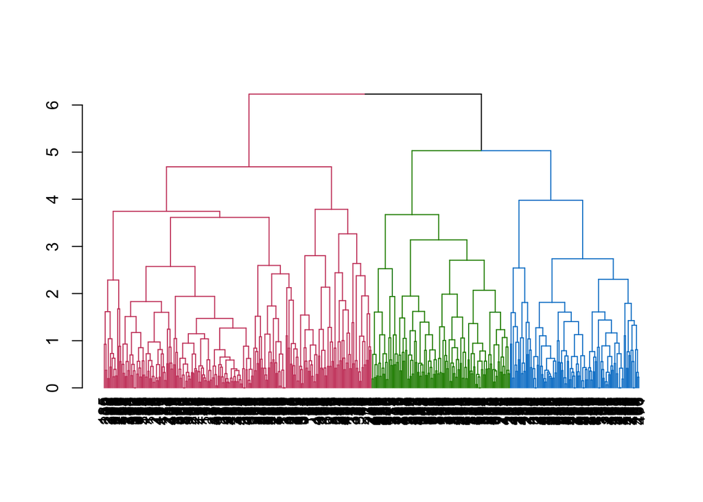

```r
library(dendextend)
#what are the k = 3 clusters identified by the dendrogram?
student.hc.dend = set(student.hc.dend, "branches_k_color", k = 3)
plot(student.hc.dend)
```

Note that `student.hc.dend` must be correctly defined; you should have done this in Part B.

In your submission, please turn in the dendrogram with $k = 3$ colors. However, on your own, try setting $k = 2$, $k = 4$, and $k = 5$. Then, answer the following in 1-3 sentences: How is this code deciding which branches to color (e.g., which ones should be one color, which ones should be another color, etc.)? Your answer doesn’t have to be mathematical; your grandma should be able to understand your answer. (Or if your grandma is a statistician…your grandpa.) You can wait until after the lab to write a formal answer, but ask for help if you don’t immediately know the answer here!

*Setting `"branches_k_color"` splits the dendrogram into $k$ different colors, and these splits occur where the tree “splits” first, going from top to bottom. For example, let’s start at the top of our $k = 3$ tree: The tree splits into two pieces (denoted by a horizontal line around 6), so these two branches will receive two different colors for sure. Then, the next highest horizontal line is around 5 - this is the next time that the tree “splits,” so the color is “split” as well. At this point we have all $k = 3$ of our colors, so the whole dendrogram is colored according to these splits.*

4. (15pts) Part C shows us the $k = 3$ clusters that the dendrogram is identifying. To see if the clusters align with a categorical variable in the data, we can color the leaf labels at the bottom of the plot by a categorical variable.

We’ll color the leaves by the `Grade` variable, because it also has $k = 3$ levels. Because we’re using base `R`, we first need to define a vector of colors based on the `Grade` variable. The following line of code does this for you:

```r
grade.colors = ifelse(data$Grade == "H", "blue",
                      ifelse(data$Grade == "M", "green", "red"))
```

where `data` is the dataset I defined at the beginning of this lab. (There are also fancier ways to do this in `tidyverse`, but I’m being old-school here.)

Now we’re going to use the `set` function again to define the color of the leaf labels at the bottom of your dendrogram. To do this, run the following line of code only *after* you’ve successfully run the code from Part C:

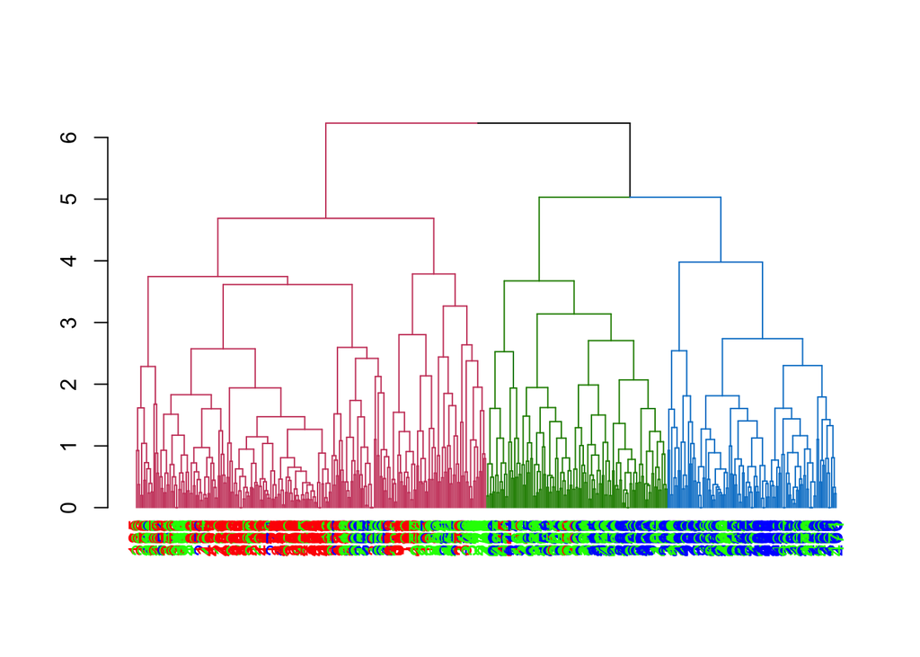

```r
student.hc.dend = set(student.hc.dend, "labels_colors", order_value = TRUE, grade.colors)
plot(student.hc.dend)
```

I asked you to run the above code only *after* you’ve run the code from Part C, because that way, the branch colors *and* leaf colors will have been “set”. Having `order_value = TRUE` is also very important - you should always use it when setting the leaf label colors in this way. In the background, the dendrogram is reordering the data, so `order_value = TRUE` is telling `R`, “Hey, my colors are in the order of my data, not the order you created, `R`!”

Your submission for this problem should have a dendrogram with branches that are three different colors and leaf labels that are three different colors defined by the `Grade` variable. Then, answer the following in 1-3 sentences: To what extent are the three clusters identified by the dendrogram (i.e., the branch colors) just the three `Grade` values (i.e., the leaf colors) in the dataset? For example, does each cluster identified by the dendrogram consist of just one type of `Grade`, or at least mostly one type of `Grade`? Or is there a mix of `Grade` types across all of the clusters?

Again, you can wait until after the lab to fully answer this question, but be sure to ask for help if you’re not immediately sure what the answer will be. Also, note that I decided to make the leaf colors red, green, and blue, which will correspond to the branch colors; but in general, the leaf colors *do not* have to correspond to the branch colors.

*For each of the three clusters identified by the dendrogram (denoted by the branch colors), there is at least some heterogeneity in terms of the `Grade` variable, but some `Grade` values are definitely more prominent than others for each of the clusters. In particular:*

- *The right-hand cluster tends to have students with high grades (denoted by blue leaf labels). There are also a few students with medium grades (denoted by green leaf labels).*
- *The center cluster tends to have students with medium grades. There are also some students with high grades.*
- *The left-hand cluster is the most heterogeneous, but it tends to have students with low grades (denoted by red leaf labels). There are also a fair number of students with medium grades.*

# Problem 2: Principal Component Analysis (50 points)

Now we will visualize the student dataset using principal component analysis (PCA). In particular, we will reduce the 4-dimensional dataset to just 2 dimensions. This isn’t a large dimension reduction, but it will help us understand what PCA is doing.

1. (5pts): First, perform the following steps (the first two you should have already done in Part A of Problem 1, so you can just copy-and-paste your code here):
- Create a subset of the student data that only contains the four quantitative variables `RaisedHands`, `VisitedResources`, `AnnouncementsView`, and `Discussion`. Define this as `data.subset`.

```r
data.subset = subset(data, select = c(RaisedHands, VisitedResources, AnnouncementsView, Discussion))
```

- **Center your variables** by subtracting from each column its mean (i.e., redefine the column as the column minus its mean). If you’re unsure how to do this step, ask for help or see the Lecture 17 R demo.

```r
data.subset = apply(data.subset, MARGIN = 2, FUN = function(x) x - mean(x))
```

- **Standardize your variables** by dividing each column by its standard deviation.

```r
data.subset = apply(data.subset, MARGIN = 2, FUN = function(x) x/sd(x))
```

After you’ve performed these steps, the following lines of code will give you 1 and approximately 0, respectively:

```r
var(data.subset[,1])
```

```
## [1] 1
```

```r
mean(data.subset[,1])
```

```
## [1] 4.079762e-17
```

It’s okay that the mean is not exactly zero; this is just due to rounding error in R.

For this part, all you need to do is write code for the appropriate subsetting, centering, and standardizing, and then uncomment the above line of code to show that the variance is 1 and the mean is (approximately) 0 for each column.

2. (5pts) If you did Part A correctly, you should be able to do the following tasks:
- Define `data.pca` as `prcomp(data.subset)`.

```r
data.pca = prcomp(data.subset)
```

- Run `summary(data.pca)`.

```r
summary(data.pca)
```

```
## Importance of components:
##                           PC1    PC2     PC3    PC4
## Standard deviation     1.5839 0.9030 0.61476 0.5459
## Proportion of Variance 0.6271 0.2039 0.09448 0.0745
## Cumulative Proportion  0.6271 0.8310 0.92550 1.0000
```

After you’ve done this, answer the following questions:

- What proportion of the total variation in the data is accounted by the first principal component?

*It looks like 0.6271 = 62.71% of the total variation is accounted by the first principal component.*

- What proportion of the total variation in the data is accounted by the second principal component?

*It looks like 0.2039 = 20.39% of the total variation is accounted by the second principal component.*

3. (15pts) Now we will make an elbow plot, where the proportion of total variation of each component is on the y-axis, and the component number is on the x-axis. To make an elbow plot, follow these steps:
- After `data.pca` is defined, run the following line of code:

```r
summary(data.pca)$importance["Proportion of Variance",]
```

```
##     PC1     PC2     PC3     PC4
## 0.62715 0.20387 0.09448 0.07450
```

You should get back a 4-length vector, where each element corresponds to the proportion of variation (which you used in Part B). Define this 4-length vector as `varProps`.

```r
varProps = summary(data.pca)$importance["Proportion of Variance",]
```

- Now, make a scatterplot where `varProps` is on the y-axis and the numbers 1, 2, 3, 4 (`1:4`) are on the x-axis. You can do this using the base R `plot()` function (as shown in the Lecture 17 R demo) or you can use `ggplot()` by putting `varProps` and `1:4` into its own `data.frame` (and then using `geom_point()` and `geom_line()`). The goal is to craete the classic “elbow plot” that we discussed at the end of last lecture.

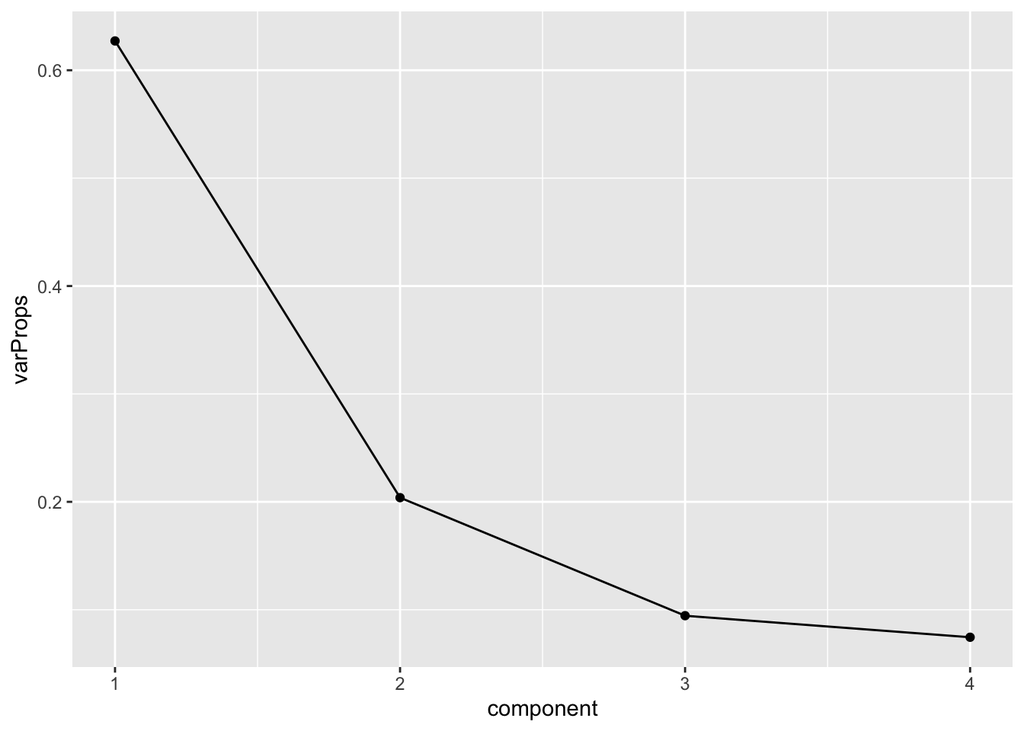

```r
varProps.df = data.frame(component = 1:4, varProps)
library(tidyverse)
ggplot(varProps.df, aes(x = component, y = varProps)) + geom_point() + geom_line()
```

After you’ve made the elbow plot: Where do you think the “elbow” is in this plot? In other words, how many components do you think should be used when visualizing this dataset? Provide a 1-2 sentence explanation of your answer.

*From this plot, it appears that the “elbow” is at $k = 2$, suggesting that $k = 2$ components should be used when visualizing this dataset. We say that the “elbow” occurs at $k = 2$ because the proportion of variation appears to decrease a lot from 1 to 2, but appears to “level off” afterwards (i.e., the line appears to become much more flat after $k = 2$). This suggests that the marginal benefit of including more than $k = 2$ components is fairly small, thereby suggesting that it is appropriate to only use $k = 2$ components. [Note, however, that a similar argument could be made for $k = 3$ - that is an equally good response to this question. However, $k = 1$ and $k = 4$ are definitely incorrect.]*

**Note**: Because this is already a low-dimensional dataset, the choice of “elbow” may not be as clear - just provide your reasoning, regardless of your choice. Please ask for help if it’s unclear how you identify the “elbow” in an elbow plot in general.

4. (15pts) Now we will make a scatterplot of the first two principal components using `ggplot()`, colored by `Grade` within the original `data` (defined at the beginning of this lab). To do this, follow these steps:
- Run the following code to define the principal components, and convert it to a `data.frame`:

```r
#the matrix of covariates
X = as.matrix(data.subset)
#the principal components, which are
#defined as X times the rotation matrix:
prinComps = X%*%data.pca$rotation
#convert to a data.frame
prinComps = as.data.frame(prinComps)
```

This assumes that you’ve already defined `data.subset` and `data.pca` correctly (see Question 2A and Question 2B, respectively). It is your responsibility to understand what this code is doing - ask for help if you don’t understand!

- Note that `data$Grade` provides the grade of each student in the dataset (either low, medium, or high). Add `Grade` to the `prinComps` dataset.

```r
prinComps$Grade = data$Grade
```

- Now you should have a single `data.frame` called `prinComps`, which contains the principal components and `Grade`. Using this, make the desired scatterplot, which the first principal component (`PC1`) on the x-axis and the second principal component (`PC2`) on the y-axis, with points colored by `Grade`.

[For this part, all you have to do is make the desired scatterplot. However, you should ask yourself: Does `Grade` seem to be associated with any of the principal components?]

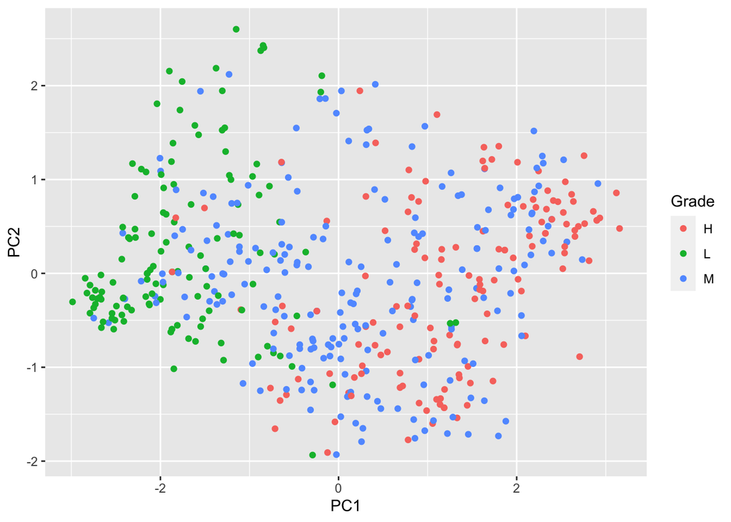

```r
ggplot(prinComps, aes(x = PC1, y = PC2)) + geom_point(aes(color = Grade))
```

*Yes, it appears that `Grade` is associated with the first principal component: Students with a low first prinicpal component tend to have a low grade, and students with a high first principal component tend to have a high grade. However, there does not seem to be a strong association between `Grade` and the second principal component.*

*[Note: If you go back to the Lecture 15 R Demo, you’ll find that this plot is actually identical to the equivalent MDS plot for these data. This is because, when the Euclidean distance is used, the first two dimensions of MDS are actually equivalent to the first two principal components. (Discussing as to why is outside the scope of this class - but in short, it is because both MDS and PCA rely on an eigenvector decomposition of the covariates’ covariance matrix.) PCA provides some additional value over MDS, however: The elbow plot allows us to determine what $k$ should be, and it is more straightforward to determine how the principal components are related to the original variables in the data, as we’ll see on the homework.]*

5. (10pts) In Part D you should have made a scatterplot of the first two principal components. In this part, copy-and-paste your Part D code, and add a single linear regression line to the plot (without confidence intervals). Be sure there is a *single* regression line in the plot.

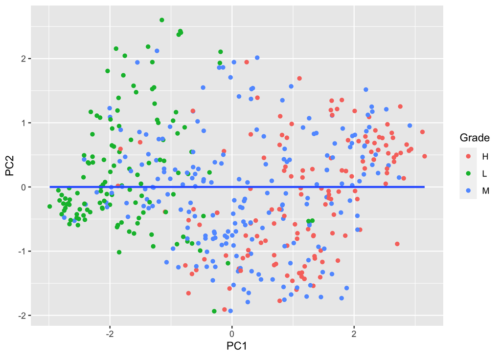

```r
ggplot(prinComps, aes(x = PC1, y = PC2)) + geom_point(aes(color = Grade)) + geom_smooth(method = "lm", se = FALSE)
```

After you’ve made the plot, answer the following question in 1-2 sentences: Why is it totally unsurprising that the linear regression line is completely flat?

*As discussed in class, the principal components are defined such that each principal component is uncorrelated with the rest of the principal components. Thus, the first and second principal components are by definition uncorrelated with each other, resulting in a flat regression line.*